# Take-home Exercise 1: Application of Spatial Point Pattern Analysis on Grab Hailing Service in Singapore

Author

Tang Xin Yi

Published

January 17, 2024

# 1 Problem context

This exercise is looking into discovering insights relevant to the geographical and spatial distribution of Grab hailing service locations in Singapore.

In this exercise, the following packages are used.

```r
pacman::p_load(sf, tidyverse, tmap, spatstat, raster, maptools, spNetwork, classInt, viridis, arrow, lubridate)
```

# 2 Data

## 2.1 Background of the datasets used

The following datasets are used in this analysis exercise.

- `GrabPosisi`: Aspatial data
- `RoadMap`: from OpenStreetMap
- `Master Plan 2019 Subzone Boundary (No Sea)` from Data.gov.sg

## 2.2 Import data

```r
grab <- read_parquet("../../data/aspatial/GrabPosisi/part-00000-8bbff892-97d2-4011-9961-703e38972569.c000.snappy.parquet")

roadmap <- st_read(dsn = "../../data/geospatial/malaysia-singapore-brunei-latest-free.shp",
                   layer = "gis_osm_roads_free_1")
mp19 <- st_read("../../data/geospatial/MasterPlan2019SubzoneBoundaryNoSeaKML.kml")
```

From below, `grab$pingtimestamp` is not in the correct data type (it is in int class)

```r
head(grab)
```

```
# A tibble: 6 × 9
  trj_id driving_mode osname  pingtimestamp rawlat rawlng speed bearing accuracy
  <chr>  <chr>        <chr>           <int>  <dbl>  <dbl> <dbl>   <int>    <dbl>
1 70014  car          android    1554943236   1.34   104.  18.9     248      3.9
2 73573  car          android    1555582623   1.32   104.  17.7      44      4
3 75567  car          android    1555141026   1.33   104.  14.0      34      3.9
4 1410   car          android    1555731693   1.26   104.  13.0     181      4
5 4354   car          android    1555584497   1.28   104.  14.8      93      3.9
6 32630  car          android    1555395258   1.30   104.  23.2      73      3.9
```

```r
grab$pingtimestamp = as_datetime(grab$pingtimestamp)
```

Now the `pingtimestamp` is in the correct data type `POSIXct` which represents datetime in tibble

```r
head(grab)
```

```
# A tibble: 6 × 9
  trj_id driving_mode osname  pingtimestamp       rawlat rawlng speed bearing
  <chr>  <chr>        <chr>   <dttm>               <dbl>  <dbl> <dbl>   <int>
1 70014  car          android 2019-04-11 00:40:36   1.34   104.  18.9     248
2 73573  car          android 2019-04-18 10:17:03   1.32   104.  17.7      44
3 75567  car          android 2019-04-13 07:37:06   1.33   104.  14.0      34
4 1410   car          android 2019-04-20 03:41:33   1.26   104.  13.0     181
5 4354   car          android 2019-04-18 10:48:17   1.28   104.  14.8      93
6 32630  car          android 2019-04-16 06:14:18   1.30   104.  23.2      73
# ℹ 1 more variable: accuracy <dbl>
```

There are Z dimensions in `mp19` multipolygon Z, drop Z dimensions to keep the multipolygons

```r
mp19 <- st_zm(mp19$geometry, drop = TRUE, what = "ZM")
```

The tibble data.frame is using coordinate system `WGS 84`, but we want to use the data in `SVY21`

```r
st_crs(mp19)
```

```
Coordinate Reference System:
  User input: WGS 84
  wkt:
GEOGCRS["WGS 84",
    DATUM["World Geodetic System 1984",
        ELLIPSOID["WGS 84",6378137,298.257223563,
            LENGTHUNIT["metre",1]]],
    PRIMEM["Greenwich",0,
        ANGLEUNIT["degree",0.0174532925199433]],
    CS[ellipsoidal,2],
        AXIS["geodetic latitude (Lat)",north,
            ORDER[1],
            ANGLEUNIT["degree",0.0174532925199433]],
        AXIS["geodetic longitude (Lon)",east,
            ORDER[2],
            ANGLEUNIT["degree",0.0174532925199433]],
    ID["EPSG",4326]]
```

```r
mp19 <- st_transform(mp19, crs = 3414)
head(mp19)
```

```
Geometry set for 6 features
Geometry type: MULTIPOLYGON
Dimension:     XY
Bounding box:  xmin: 24431.8 ymin: 28515.07 xmax: 30213.96 ymax: 29882
Projected CRS: SVY21 / Singapore TM
First 5 geometries:
```

```
MULTIPOLYGON (((25910.34 29425.34, 26265.82 292...
```

```
MULTIPOLYGON (((26750.09 29216.1, 26751.91 2917...
```

```
MULTIPOLYGON (((29161.2 29723.07, 29189.03 2970...
```

```
MULTIPOLYGON (((29814.11 29616.89, 29806.68 295...
```

```
MULTIPOLYGON (((30137.77 29843.19, 30138.42 298...
```

```r
head(roadmap)
```

```
Simple feature collection with 6 features and 10 fields
Geometry type: LINESTRING
Dimension:     XY
Bounding box:  xmin: 101.7033 ymin: 1.305992 xmax: 103.8301 ymax: 3.147986
Geodetic CRS:  WGS 84
   osm_id code      fclass                   name  ref oneway maxspeed layer
1 4386520 5113     primary           Orchard Road <NA>      F       50     0
2 4578273 5114   secondary    Jalan Bukit Bintang <NA>      F        0     0
3 4579495 5122 residential         Jalan Nagasari <NA>      B        0     0
4 4579533 5122 residential  Persiaran Raja Chulan <NA>      B        0     0
5 4579534 5122 residential           Jalan Ceylon <NA>      B        0     0
6 4579536 5122 residential Changkat Bukit Bintang <NA>      F        0     0
  bridge tunnel                       geometry
1      F      F LINESTRING (103.8301 1.3060...
2      F      F LINESTRING (101.7226 3.1478...
3      F      F LINESTRING (101.7084 3.1473...
4      F      F LINESTRING (101.7043 3.1468...
5      F      F LINESTRING (101.7033 3.1476...
6      F      F LINESTRING (101.7088 3.1470...
```

```r
st_crs(roadmap)
```

```
Coordinate Reference System:
  User input: WGS 84
  wkt:
GEOGCRS["WGS 84",
    DATUM["World Geodetic System 1984",
        ELLIPSOID["WGS 84",6378137,298.257223563,
            LENGTHUNIT["metre",1]]],
    PRIMEM["Greenwich",0,
        ANGLEUNIT["degree",0.0174532925199433]],
    CS[ellipsoidal,2],
        AXIS["latitude",north,
            ORDER[1],
            ANGLEUNIT["degree",0.0174532925199433]],
        AXIS["longitude",east,
            ORDER[2],
            ANGLEUNIT["degree",0.0174532925199433]],
    ID["EPSG",4326]]
```

`roadmap` has a similar problem as `mp19`, the coordinate system needs to be changed to `SVY 21`

```r
roadmap <- st_transform(roadmap, crs = 3414)
head(roadmap)
```

```
Simple feature collection with 6 features and 10 fields
Geometry type: LINESTRING
Dimension:     XY
Bounding box:  xmin: -208807.5 ymin: 32035.45 xmax: 27643.1 ymax: 235953.4
Projected CRS: SVY21 / Singapore TM
   osm_id code      fclass                   name  ref oneway maxspeed layer
1 4386520 5113     primary           Orchard Road <NA>      F       50     0
2 4578273 5114   secondary    Jalan Bukit Bintang <NA>      F        0     0
3 4579495 5122 residential         Jalan Nagasari <NA>      B        0     0
4 4579533 5122 residential  Persiaran Raja Chulan <NA>      B        0     0
5 4579534 5122 residential           Jalan Ceylon <NA>      B        0     0
6 4579536 5122 residential Changkat Bukit Bintang <NA>      F        0     0
  bridge tunnel                       geometry
1      F      F LINESTRING (27637.52 32038....
2      F      F LINESTRING (-206660 235943....
3      F      F LINESTRING (-208246.4 23589...
4      F      F LINESTRING (-208704.9 23583...
5      F      F LINESTRING (-208807.5 23591...
6      F      F LINESTRING (-208200.4 23585...
```

## 2.3 Prepare required Geographical data layers

This exercise needs the following geographical data layers

1. Grab taxi location points either by origins or destinations
2. Road layer within Singapore excluding outer islands
3. Singapore boundary layer excluding outer islands

### 2.3.1 Get Grab taxi origin and destination layer

Get the origin tibble data.frame

```r
trip_origin <- grab %>%
  # group by trip id
  group_by(trj_id) %>%
  # sort: ascending by default
  arrange(pingtimestamp, .by_group = FALSE) %>%
  # get 1st row
  filter(row_number()==1) %>%
  mutate(weekday = wday(pingtimestamp,
                        label = TRUE,
                        abbr = TRUE),
         start_hr = factor(hour(pingtimestamp)),
         day = factor(mday(pingtimestamp)))
```

Get the destination tibble data.frame

Converting `rawlat` and `rawlng` with formula provided in this [StackOverflow tread](https://stackoverflow.com/questions/1185408/converting-from-longitude-latitude-to-cartesian-coordinates)

```r
trip_dest <- grab %>%
  group_by(trj_id) %>%
  arrange(desc(pingtimestamp), .by_group = FALSE) %>%
  filter(row_number()==1) %>%
  mutate(weekday = wday(pingtimestamp,
                        label = TRUE,
                        abbr = TRUE),
         end_hr = factor(hour(pingtimestamp)),
         day = factor(mday(pingtimestamp)))
```

The extracted data layers are written into `rds` files for easier reference later.

```r
write_rds(trip_origin, "../../data/rds/trip_origin.rds")
write_rds(trip_dest, "../../data/rds/trip_dest.rds")
```

### 2.3.3 Get Singapore boundary layer

This part is using `mp19` and `roadmap`

Do a quick plot of the union to get the boundary layer

Use of `subset()` function credited to `Anonymous Calc` from [Piazza](https://piazza.com/class/lqua3egki6w3oi/post/48)

```r
lengths(mp19)
```

```
  [1] 1 1 1 1 1 1 1 1 1 1 1 1 1 1 1 6 1 1 1 1 1 1 1 1 1 1 1 8 4 9 8 1 1 1 1 1 1
 [38] 1 1 1 1 1 1 1 1 1 1 1 1 1 1 1 1 1 1 1 1 1 1 1 1 1 1 1 1 1 1 1 1 1 1 1 1 1
 [75] 1 1 1 1 1 1 1 1 1 1 1 1 1 1 1 1 1 1 1 1 1 1 1 1 1 1 1 1 1 1 1 1 1 1 2 1 1
[112] 1 1 1 1 1 1 1 1 1 1 1 1 1 1 1 1 1 1 1 1 1 1 1 1 1 1 1 1 1 1 1 1 1 1 1 1 1
[149] 1 1 1 1 1 1 1 1 1 1 4 1 1 1 1 1 1 1 1 1 1 1 1 1 1 1 1 1 1 1 1 1 1 1 1 1 1
[186] 1 1 1 1 1 1 1 1 1 1 1 1 1 1 1 1 1 1 1 1 1 1 1 1 1 1 1 1 1 1 1 1 1 1 1 1 1
[223] 1 1 1 1 1 1 1 1 1 1 1 1 1 1 1 1 1 1 1 1 1 1 1 1 1 1 1 1 1 1 1 1 1 1 1 1 1
[260] 1 1 1 1 1 1 1 1 1 1 1 1 1 1 1 1 1 1 1 1 1 1 1 1 1 1 1 1 1 1 1 1 1 1 1 1 1
[297] 1 1 1 1 1 2 1 1 1 1 3 1 1 1 1 1 1 1 1 1 1 4 1 1 1 1 1 1 1 1 1 1 1 1 1 3
```

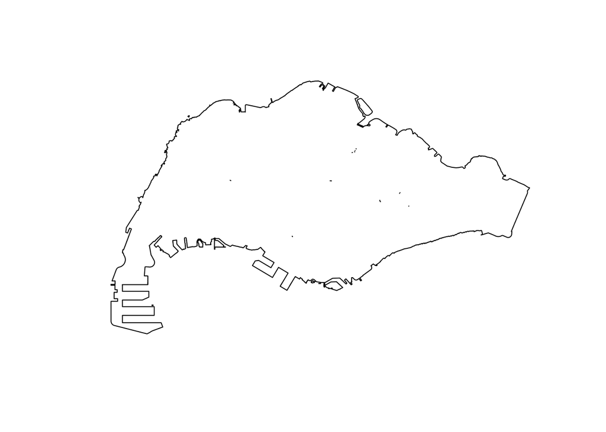

```r
mp19main <- subset(mp19, lengths(mp19) <= 3 )
plot(st_union(mp19main))
```

```r
summary(mp19main)
```

```
 MULTIPOLYGON     epsg:3414 +proj=tmer...
          325             0             0
```

Save the boundary layer into RDS file

```r
write_rds(st_union(mp19main), "../../data/rds/sg_bount.rds")
```

### 2.3.2 Get Road layer within Singapore

Overlap the 2 dataframe to get only roads for Singapore

```r
road_sg <- st_intersection(roadmap, mp19main)
```

Zoom in to see the roads via ID

```r
tmap_mode("plot")
```

```
tmap mode set to plotting
```

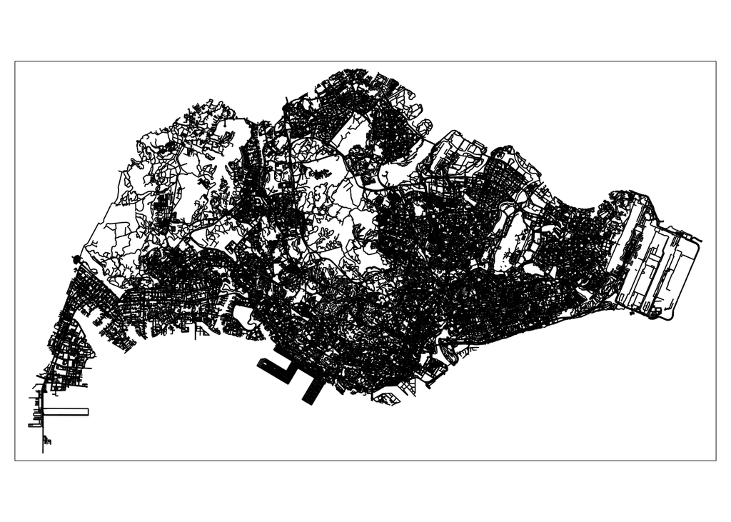

```r
tm_shape(road_sg)+
  tm_lines()
```

Extract out the road layer

```r
write_rds(road_sg, "../../data/rds/road_sg.rds")
```

# 3 Kernel Density Estimation

From here on, the rds files would be used instead of the original data files.

```r
road <- read_rds("../../data/rds/road_sg.rds")
sg_boun <- read_rds("../../data/rds/sg_bount.rds")
trip_origin <- read_rds("../../data/rds/trip_origin.rds")
trip_dest <- read_rds("../../data/rds/trip_dest.rds")

st_crs(sg_boun)
```

```
Coordinate Reference System:
  User input: EPSG:3414
  wkt:
PROJCRS["SVY21 / Singapore TM",
    BASEGEOGCRS["SVY21",
        DATUM["SVY21",
            ELLIPSOID["WGS 84",6378137,298.257223563,
                LENGTHUNIT["metre",1]]],
        PRIMEM["Greenwich",0,
            ANGLEUNIT["degree",0.0174532925199433]],
        ID["EPSG",4757]],
    CONVERSION["Singapore Transverse Mercator",
        METHOD["Transverse Mercator",
            ID["EPSG",9807]],
        PARAMETER["Latitude of natural origin",1.36666666666667,
            ANGLEUNIT["degree",0.0174532925199433],
            ID["EPSG",8801]],
        PARAMETER["Longitude of natural origin",103.833333333333,
            ANGLEUNIT["degree",0.0174532925199433],
            ID["EPSG",8802]],
        PARAMETER["Scale factor at natural origin",1,
            SCALEUNIT["unity",1],
            ID["EPSG",8805]],
        PARAMETER["False easting",28001.642,
            LENGTHUNIT["metre",1],
            ID["EPSG",8806]],
        PARAMETER["False northing",38744.572,
            LENGTHUNIT["metre",1],
            ID["EPSG",8807]]],
    CS[Cartesian,2],
        AXIS["northing (N)",north,
            ORDER[1],
            LENGTHUNIT["metre",1]],
        AXIS["easting (E)",east,
            ORDER[2],
            LENGTHUNIT["metre",1]],
    USAGE[
        SCOPE["Cadastre, engineering survey, topographic mapping."],
        AREA["Singapore - onshore and offshore."],
        BBOX[1.13,103.59,1.47,104.07]],
    ID["EPSG",3414]]
```

```r
st_crs(trip_origin)
```

```
Coordinate Reference System: NA
```

```r
st_crs(trip_dest)
```

```
Coordinate Reference System: NA
```

According to the steps in In-class Exercises 3, the tibble needs to be wrangled.

## 3.1 Geospatial data wrangling

`sf` is preferred, convert to `sf`

Upon investigation, the window size of the `trip_origin` and `sg_boun` differs too much.

With reference to this [page](https://rstudio-pubs-static.s3.amazonaws.com/19879_7e13ab80d5ed416c8e235bd6bb93cf3e.html), the lat-long values are converted into SVY21 XY coordinates.

```r
class(trip_origin)
```

```
[1] "grouped_df" "tbl_df"     "tbl"        "data.frame"
```

```r
class(trip_dest)
```

```
[1] "grouped_df" "tbl_df"     "tbl"        "data.frame"
```

```r
class(sg_boun)
```

```
[1] "sfc_MULTIPOLYGON" "sfc"
```

```r
# setting existing coordinate as lat-long system
trip_origin_sp_dec <- SpatialPoints(coords = cbind(trip_origin$rawlng, trip_origin$rawlat),
                                    proj4string = CRS("+proj=longlat"))
trip_origin_sp_svy <- spTransform(trip_origin_sp_dec,
                                  CRS("+init=epsg:3414"))
trip_dest_sp_dec <- SpatialPoints(coords = cbind(trip_dest$rawlng, trip_dest$rawlat),
                                  proj4string = CRS("+proj=longlat"))
trip_dest_sp_svy <- spTransform(trip_dest_sp_dec,
                                CRS("+init=epsg:3414"))
```

Create `ppp` object from the `sf` objects

```r
trip_origin_ppp <- as(trip_origin_sp_svy, "ppp")
summary(trip_origin_ppp)
```

```
Planar point pattern:  28000 points
Average intensity 2.47621e-05 points per square unit

Coordinates are given to 3 decimal places
i.e. rounded to the nearest multiple of 0.001 units

Window: rectangle = [3661.47, 49845.23] x [25201.14, 49685.08] units
                    (46180 x 24480 units)
Window area = 1130760000 square units
```

```r
trip_dest_ppp <- as(trip_dest_sp_svy,"ppp")
summary(trip_dest_ppp)
```

```
Planar point pattern:  28000 points
Average intensity 2.502667e-05 points per square unit

Coordinates are given to 3 decimal places
i.e. rounded to the nearest multiple of 0.001 units

Window: rectangle = [3638.69, 50024.92] x [25350.05, 49469.41] units
                    (46390 x 24120 units)
Window area = 1118810000 square units
```

Check na values

```r
sum(is.na(trip_origin_ppp))
```

```
[1] 0
```

```r
sum(is.na(trip_dest_ppp))
```

```
[1] 0
```

Handle duplicated datapoints

```r
any(duplicated(trip_origin_ppp))
```

```
[1] FALSE
```

```r
any(duplicated(trip_dest_ppp))
```

```
[1] FALSE
```

Count the number of co-incidence points

```r
sum(multiplicity(trip_origin_ppp) > 1)
```

```
[1] 0
```

```r
sum(multiplicity(trip_dest_ppp) > 1)
```

```
[1] 0
```

Converting `sg_boun` into `owin` object

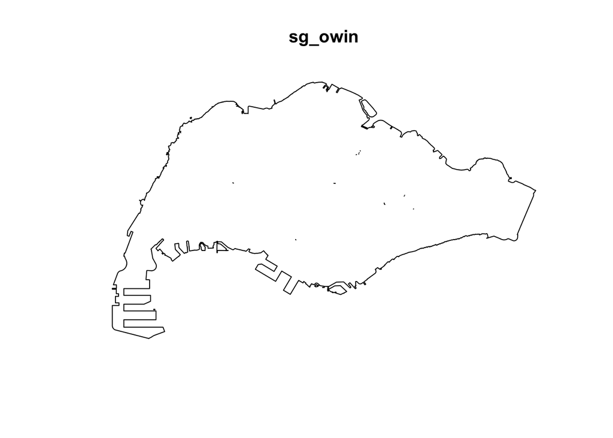

```r
sg_owin <- as.owin(sg_boun)
plot(sg_owin)
```

```r
summary(sg_owin)
```

```
Window: polygonal boundary
35 separate polygons (29 holes)
                  vertices         area relative.area
polygon 1            12396  6.61065e+08      9.98e-01
polygon 2              285  1.61128e+06      2.43e-03
polygon 3               27  1.50315e+04      2.27e-05
polygon 4 (hole)        41 -4.01660e+04     -6.06e-05
polygon 5 (hole)       317 -5.11280e+04     -7.72e-05
polygon 6 (hole)         3 -4.14100e-04     -6.25e-13
polygon 7               30  2.80002e+04      4.23e-05
polygon 8 (hole)         4 -2.86396e-01     -4.32e-10
polygon 9 (hole)         3 -1.81439e-04     -2.74e-13
polygon 10 (hole)        3 -8.68789e-04     -1.31e-12
polygon 11 (hole)        3 -5.99531e-04     -9.05e-13
polygon 12 (hole)        3 -3.04560e-04     -4.60e-13
polygon 13 (hole)        3 -4.46108e-04     -6.73e-13
polygon 14 (hole)        3 -3.39815e-04     -5.13e-13
polygon 15 (hole)        3 -4.52041e-05     -6.82e-14
polygon 16 (hole)        3 -3.90173e-05     -5.89e-14
polygon 17 (hole)        3 -9.59845e-05     -1.45e-13
polygon 18 (hole)        4 -2.54488e-04     -3.84e-13
polygon 19 (hole)        4 -4.28453e-01     -6.47e-10
polygon 20 (hole)        4 -2.18619e-04     -3.30e-13
polygon 21 (hole)        5 -2.44408e-04     -3.69e-13
polygon 22 (hole)        5 -3.64686e-02     -5.50e-11
polygon 23 (hole)        6 -8.37554e-01     -1.26e-09
polygon 24 (hole)       38 -7.79904e+03     -1.18e-05
polygon 25 (hole)        3 -3.41897e-05     -5.16e-14
polygon 26 (hole)        3 -3.65499e-03     -5.52e-12
polygon 27 (hole)        3 -4.95057e-02     -7.47e-11
polygon 28 (hole)        5 -2.92235e-04     -4.41e-13
polygon 29 (hole)        3 -7.43615e-06     -1.12e-14
polygon 30 (hole)      270 -1.21455e+03     -1.83e-06
polygon 31 (hole)       19 -4.39650e+00     -6.63e-09
polygon 32 (hole)       35 -1.38385e+02     -2.09e-07
polygon 33 (hole)       23 -1.99656e+01     -3.01e-08
polygon 34              71  5.63061e+03      8.50e-06
polygon 35              10  1.99717e+02      3.01e-07
enclosing rectangle: [2667.54, 50271.73] x [21448.47, 50256.33] units
                     (47600 x 28810 units)
Window area = 662624000 square units
Fraction of frame area: 0.483
```

Combine `trip_dest_ppp` and `trip_origin_ppp` to `sg_owin`

```r
trip_originSG_ppp <- trip_origin_ppp[sg_owin]
trip_destSG_ppp <- trip_dest_ppp[sg_owin]
```

## 3.2 Calculation

Auto bandwidth with different kernel function for `trip_origin`

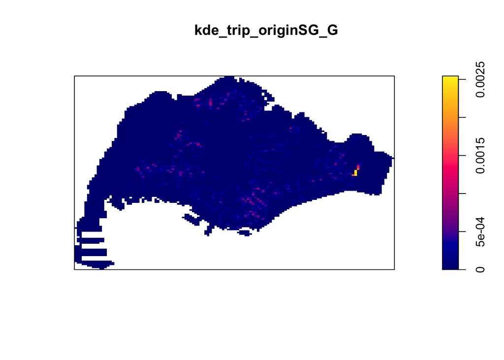

```r
kde_trip_originSG_G <- density(trip_originSG_ppp,
                                sigma = bw.diggle,
                                edge = TRUE,
                                kernel = "gaussian")
plot(kde_trip_originSG_G)
```

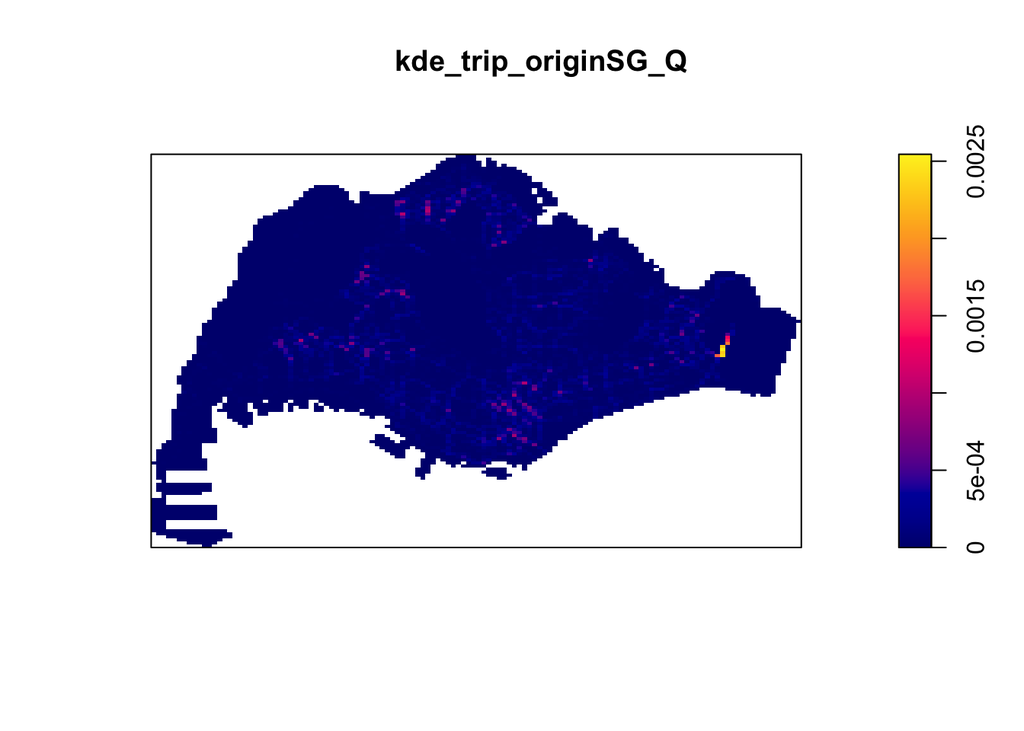

```r
kde_trip_originSG_Q <- density(trip_originSG_ppp,
                                sigma = bw.diggle,
                                edge = TRUE,
                                kernel = "quartic")
plot(kde_trip_originSG_Q)
```

Most number of trips begin at the east side of Singapore

# 4 Network-constrained Kernel Density Estimation